# タイプ相性ネットワーク分析のグラフ作成コード (R言語)

名古屋大学大学院 情報学研究科 複雑系科学専攻 鈴木琳久

2025-10-01

## はじめに

ここでは、タイプ相性ネットワークを分析するにあたって必要な「グラフの作成」を行います。

コードを以下のような手順に分けて解説します。コード全体は最後に記載しています。

- 手順①：csvファイルの読み込み
- 手順②：有向ネットワークの構築
- 手順③：次数中心性の出力
- 手順④：媒介中心性の出力
- 手順⑤：固有ベクトル中心性の出力
- 手順⑥：次数中心性の散布図の作成
- 手順⑦：媒介中心性と固有ベクトル中心性の散布図の作成
- 手順⑧：スコアの計算

※注意①：実行する際は、事前にcsvファイルをダウンロードしてください。

ダウンロードはこちら:https://github.com/rikuli-35/seminar-materials/tree/main/02_data_analysis

※注意②：この説明では、初代タイプ相性をもとに作成しています。他の世代に関しても、同様の手順で行うことで結果を得られます。

## 必要なパッケージの説明

- tidyverse：データ操作と分析を行うためのパッケージ
- igraph：ネットワーク構造の作成と分析を行うためのパッケージ
- tidygraph：igraphのオブジェクトを扱いやすい形式に変換するパッケージ
- ggraph：ネットワークを可視化するためのパッケージ

## パッケージのインストール

もし、上記で説明したパッケージをダウンロードしていない場合、以下のコードを実行することで、パッケージのインストールができます。

```r
packages <- c("tidyverse", "igraph", "ggraph", "tidygraph")

installed <- packages %in% rownames(installed.packages())
if(any(!installed)) {
  install.packages(packages[!installed])
}
```

## パッケージの読み込み

下記のコードを実行するとパッケージを読み込むことができます。

```r
library(tidyverse)
library(igraph)
library(ggraph)
library(tidygraph)
```

## 手順①：csvファイルの読み込み

下記のコードを実行すると、読み込んだファイルの内容を「type_data」に格納します。

ダウンロードしたcsvファイルを選択してください。

```r
type_data <- read.csv(file.choose(), stringsAsFactors = FALSE)
```

※本資料作成時には、コードが自動で実行され、ファイル選択ができないため、以下のように、ファイルを指定するコードを実行しています。

```r
type_data <- read.csv("type_analytics_1.csv", stringsAsFactors = FALSE)
```

## 手順②：有向ネットワークの構築

下記のコードを実行すると、「type_data」の情報をもとにgraph(有向ネットワーク)が作成されます。

```r
graph <- graph_from_data_frame(type_data,directed=TRUE)
```

また、下記のコードを実行し、graph_tblを作成することで、graphの可視化をできるようにします。

グラフの分析にはgraph、可視化にはgraph_tblを使用します。

```r
graph_tbl <- as_tbl_graph(graph)
```

次に、グラフの枝の重みについて、次のように色分けを行います。 色分けは以下の通りです。

黒→0倍、青→0.5倍、グレー→1倍、赤→2倍

```r
edgecolors <- c("0" = "black", "0.5" = "blue", "1" = "gray", "2" = "red")
```

そして、下記のコードを実行することで、有向ネットワークを構築することができます。

```r
ggraph(graph_tbl,layout="circle")+geom_edge_link(aes(color=as.factor(Multiplier)),arrow=arrow(length=unit(3,'mm')),end_cap=circle(2,'mm'))+scale_edge_color_manual(values=edgecolors)+geom_node_text(aes(label=name))+theme_void()
```

以下のような図が出力されます。

※タイプ数が一番少ない初代でも15タイプあるため、各頂点を円状に配置し、なるべく見やすくなるように設計しました。

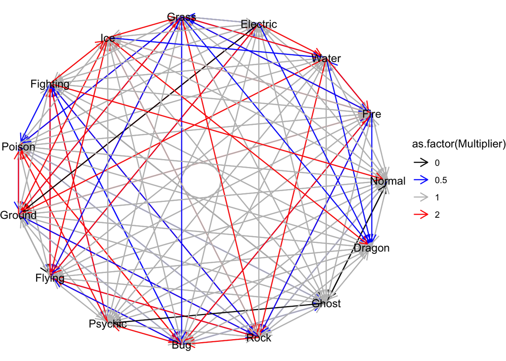

## 手順③：次数中心性の出力

下記のコードを実行すると、各タイプの入次数の合計値が出力されます。

```r
strength(graph, mode = "in", weights = E(graph)$Multiplier)
```

以下の結果が表示されます。

```
##   Normal     Fire    Water Electric    Grass      Ice Fighting   Poison
##     15.0     16.5     15.5     15.0     18.0     17.5     16.0     16.5
##   Ground   Flying  Psychic      Bug     Rock    Ghost   Dragon
##     16.0     15.5     14.0     17.5     17.0     13.0     14.0
```

また、下記のコードを実行すると、各タイプの出次数の合計値が出力されます。

```r
strength(graph, mode = "out", weights = E(graph)$Multiplier)
```

以下のような結果が表示されます。

```
##   Normal     Fire    Water Electric    Grass      Ice Fighting   Poison
##     13.5     16.0     16.5     14.5     15.0     18.0     15.0     15.0
##   Ground   Flying  Psychic      Bug     Rock    Ghost   Dragon
##     17.0     17.0     16.5     16.0     18.0     14.0     15.0
```

## 手順④：媒介中心性の出力

まず、下記のコードを実行し、各タイプの媒介中心性を計算し、「type_between」に格納します。

```r
type_between <- betweenness(graph, directed = TRUE, weight = 1 / E(graph)$Multiplier)
```

そして、下記のコードを実行することで、計算結果を降順に並び替えて表示します。

```r
sort(type_between, decreasing = TRUE)
```

以下のように結果が表示されます。

```
##      Grass       Rock        Ice     Ground        Bug     Flying   Fighting
## 11.9694444  9.9833333  8.4944444  6.4611111  5.3166667  4.8111111  4.4500000
##       Fire      Water     Poison    Psychic   Electric     Normal     Dragon
##  3.3444444  2.9444444  2.1250000  1.9027778  1.2777778  0.4166667  0.1111111
##      Ghost
##  0.0000000
```

## 手順⑤：固有ベクトル中心性の出力

まず、下記のコードを実行し、各タイプの固有ベクトル中心性を計算し、「type_eigenvector」に格納します。

```r
type_eigenvector <- eigen_centrality(graph, directed = TRUE, weights = E(graph)$Multiplier)$vector
```

そして、下記のコードを実行することで、計算結果を降順に並び替えて表示します。

```r
sort(type_eigenvector, decreasing = TRUE)
```

以下のように結果が表示されます。

```
##     Grass       Ice       Bug      Rock    Poison      Fire    Ground  Fighting
## 1.0000000 0.9640843 0.9634309 0.9412123 0.9028351 0.9025043 0.8909043 0.8667929
##     Water    Flying    Normal  Electric   Psychic    Dragon     Ghost
## 0.8529862 0.8504045 0.8339442 0.8268267 0.7878577 0.7713628 0.7016588
```

## 手順⑥：入次数と出次数の散布図の作成

まず、下記のコードを実行し、手順③で計算した入次数、出次数の合計値をそれぞれ「in_degree」、「out_degree」に格納します。

```r
in_degree <- strength(graph, mode = "in", weights = E(graph)$Multiplier)
out_degree <- strength(graph, mode = "out", weights = E(graph)$Multiplier)
```

次に、下記のコードを実行し、データフレームを作成します

```r
degree_data <- tibble(Type = names(in_degree), InDegree = as.numeric(in_degree), OutDegree = as.numeric(out_degree)) %>% mutate(DistanceSigned = (OutDegree - InDegree) / sqrt(2))
```

そして、下記のコードを実行することで、次数中心性の散布図を作成できます。

```r
ggplot(degree_data, aes(x = InDegree, y = OutDegree, label = Type)) + geom_point(aes(color = DistanceSigned), size = 3) + geom_text(vjust = -0.5, size = 3) + geom_abline(intercept = 0, slope = 1, color = "red", linetype = "dashed") + scale_color_gradient2(low = "blue", mid = "gray", high = "red", migpoint = 0, name = "Distance") + theme_minimal() + labs(x = "InDegree", y = "OutDegree")
```

以下のような結果が得られます。

グラフのx軸は入次数、y軸は出次数を表しており、入次数と出次数のバランス（相関）を視覚的に捉えるために赤色の点線(y=xの直線)を引いています。

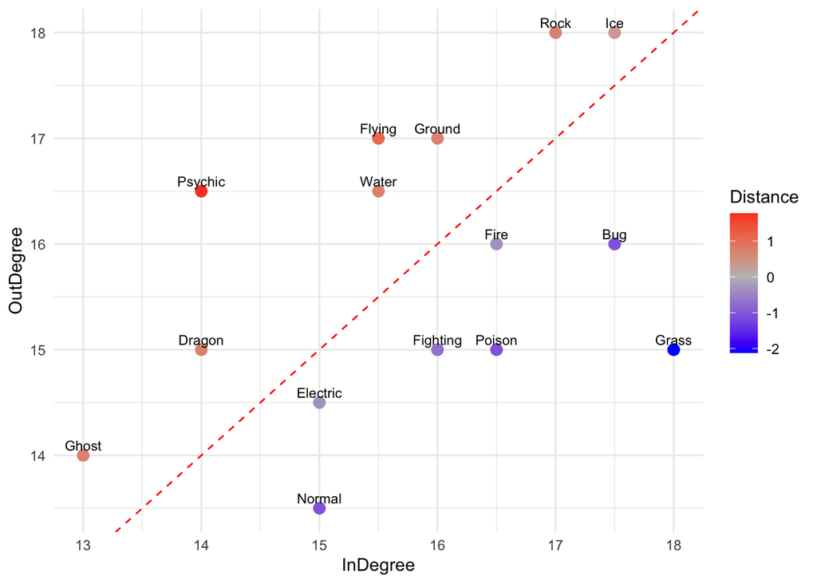

## 手順⑦：媒介中心性と固有ベクトル中心性の散布図の作成

まず、下記のコードを実行し、データフレームを作成します。

```r
bet_vec_data <- tibble(Type = names(type_between), Betweenness = as.numeric(type_between), Eigenvector = as.numeric(type_eigenvector))
```

そして、下記のコードを実行することで、媒介中心性と固有ベクトル中心性の散布図を作成できます。

```r
ggplot(bet_vec_data, aes(x = Eigenvector, y = Betweenness, label = Type)) + geom_point(color = "darkorange", size = 3) + geom_text(vjust = -0.5, size = 3) +  theme_minimal() + labs(x = "Eigenvector", y = "Betweenness")
```

以下のような結果が得られます。

グラフのx軸は固有ベクトル中心性、y軸は媒介中心性を表しています。

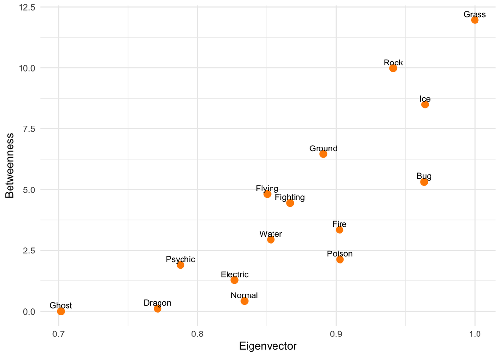

## 手順⑧：スコアの計算

まず、下記のコードを実行し、次数中心性のスコアを算出します。

```r
score_degree <- 1 - mean(abs(degree_data$DistanceSigned)) / max(abs(degree_data$DistanceSigned))
```

次に、下記コードを実行し、媒介中心性と固有ベクトル中心性のスコアを算出します。

```r
score_bet_vec <- 1 - abs(cor(bet_vec_data$Eigenvector, bet_vec_data$Betweenness))
```

そして、下記コードを実行し、総合スコアを算出します。

```r
score_total <- 0.5 * score_degree + 0.5 * score_bet_vec
```

最後に、下記コードを実行し、算出した値を出力します。

```r
cat("score_degree:", score_degree)
cat("score_bet_vec:", score_bet_vec)
cat("score_total:", score_total)
```

以下のような結果が得られます。

```
## score_degree: 0.5777778
```

```
## score_bet_vec: 0.1648264
```

```
## score_total: 0.3713021
```

## まとめ

本資料では、タイプ相性ネットワークを構築し、各中心性の値を計算し、その値をグラフにまとめる手順とそのコードを解説しました。

プロジェクトの概要の解説資料や、他のファイルでの実行結果もGitHubで一般公開してます。

- GitHubのURL：https://github.com/rikuli-35/seminar-materials/tree/main/02_data_analysis

## コード全体

```r
library(tidyverse)
library(igraph)
library(ggraph)
library(tidygraph)

type_data <- read.csv(file.choose(), stringsAsFactors = FALSE)

graph <- graph_from_data_frame(type_data,directed=TRUE)
graph_tbl <- as_tbl_graph(graph)
edgecolors <- c("0" = "black", "0.5" = "blue", "1" = "gray", "2" = "red")
ggraph(graph_tbl,layout="circle")+geom_edge_link(aes(color=as.factor(Multiplier)),arrow=arrow(length=unit(3,'mm')),end_cap=circle(2,'mm'))+scale_edge_color_manual(values=edgecolors)+geom_node_text(aes(label=name))+theme_void()

strength(graph, mode = "in", weights = E(graph)$Multiplier)
##   Normal     Fire    Water Electric    Grass      Ice Fighting   Poison
##     15.0     16.5     15.5     15.0     18.0     17.5     16.0     16.5
##   Ground   Flying  Psychic      Bug     Rock    Ghost   Dragon
##     16.0     15.5     14.0     17.5     17.0     13.0     14.0

strength(graph, mode = "out", weights = E(graph)$Multiplier)
##   Normal     Fire    Water Electric    Grass      Ice Fighting   Poison
##     13.5     16.0     16.5     14.5     15.0     18.0     15.0     15.0
##   Ground   Flying  Psychic      Bug     Rock    Ghost   Dragon
##     17.0     17.0     16.5     16.0     18.0     14.0     15.0

type_between <- betweenness(graph, directed = TRUE, weight = 1 / E(graph)$Multiplier)
sort(type_between, decreasing = TRUE)
##      Grass       Rock        Ice     Ground        Bug     Flying   Fighting
## 11.9694444  9.9833333  8.4944444  6.4611111  5.3166667  4.8111111  4.4500000
##       Fire      Water     Poison    Psychic   Electric     Normal     Dragon
##  3.3444444  2.9444444  2.1250000  1.9027778  1.2777778  0.4166667  0.1111111
##      Ghost
##  0.0000000

type_eigenvector <- eigen_centrality(graph, directed = TRUE, weights = E(graph)$Multiplier)$vector
sort(type_eigenvector, decreasing = TRUE)
##     Grass       Ice       Bug      Rock    Poison      Fire    Ground  Fighting
## 1.0000000 0.9640843 0.9634309 0.9412123 0.9028351 0.9025043 0.8909043 0.8667929
##     Water    Flying    Normal  Electric   Psychic    Dragon     Ghost
## 0.8529862 0.8504045 0.8339442 0.8268267 0.7878577 0.7713628 0.7016588

in_degree <- strength(graph, mode = "in", weights = E(graph)$Multiplier)

out_degree <- strength(graph, mode = "out", weights = E(graph)$Multiplier)
degree_data <- tibble(Type = names(in_degree), InDegree = as.numeric(in_degree), OutDegree = as.numeric(out_degree)) %>% mutate(DistanceSigned = (OutDegree - InDegree) / sqrt(2))
ggplot(degree_data, aes(x = InDegree, y = OutDegree, label = Type)) + geom_point(aes(color = DistanceSigned), size = 3) + geom_text(vjust = -0.5, size = 3) + geom_abline(intercept = 0, slope = 1, color = "red", linetype = "dashed") + scale_color_gradient2(low = "blue", mid = "gray", high = "red", migpoint = 0, name = "Distance") + theme_minimal() + labs(x = "InDegree", y = "OutDegree")

bet_vec_data <- tibble(Type = names(type_between), Betweenness = as.numeric(type_between), Eigenvector = as.numeric(type_eigenvector))
ggplot(bet_vec_data, aes(x = Eigenvector, y = Betweenness, label = Type)) + geom_point(color = "darkorange", size = 3) + geom_text(vjust = -0.5, size = 3) +  theme_minimal() + labs(x = "Eigenvector", y = "Betweenness")

score_degree <- 1 - mean(abs(degree_data$DistanceSigned)) / max(abs(degree_data$DistanceSigned))
score_bet_vec <- 1 - abs(cor(bet_vec_data$Eigenvector, bet_vec_data$Betweenness))
score_total <- 0.5 * score_degree + 0.5 * score_bet_vec
cat("score_degree:", score_degree)
cat("score_bet_vec:", score_bet_vec)
cat("score_total:", score_total)
## score_degree: 0.5777778
## score_bet_vec: 0.1648264
## score_total: 0.3713021
```